# Problem Statement

# Performing Exploratory Data Analysis

```python
df1.dtypes
```

```
Name                  object
City                  object
State                 object
Zip                    int64
Bank                  object
BankState             object
NAICS                  int64
ApprovalDate          object
ApprovalFY             int32
Term                   int64
NoEmp                  int64
NewExist             float64
CreateJob              int64
RetainedJob            int64
FranchiseCode          int64
UrbanRural             int64
RevLineCr              int32
LowDoc                 int32
DisbursementDate      object
DisbursementGross    float64
BalanceGross         float64
MIS_Status            object
ChgOffPrinGr         float64
GrAppv               float64
SBA_Appv             float64
Loan_Status          float64
RealEstate             int32
Recession              int32
dtype: object
```

```python
# 1. segregate numerical and categorical columns
```

```python
num=['Loan_Status','ApprovalFY', 'Term', 'NoEmp', 'NewExist', 'CreateJob', 'RetainedJob','UrbanRural', 'RevLineCr', 'LowDoc', 'DisbursementGross', 'BalanceGross', 'GrAppv', 'SBA_Appv', 'RealEstate', 'FranchiseCode','Recession','ChgOffPrinGr','NAICS']
#num=[['RealEstate','Recession','CreateJob', 'RetainedJob','UrbanRural', 'RevLineCr']]
df_num=df1[num]
df_num.describe()
```

|  | Loan_Status | ApprovalFY | Term | NoEmp | NewExist | CreateJob | RetainedJob | UrbanRural | RevLineCr | LowDoc | DisbursementGross | BalanceGross | GrAppv | SBA_Appv | RealEstate | FranchiseCode | Recession | ChgOffPrinGr | NAICS |
| --- | --- | --- | --- | --- | --- | --- | --- | --- | --- | --- | --- | --- | --- | --- | --- | --- | --- | --- | --- |
| count | 879965.000000 | 881914.000000 | 881914.000000 | 881914.000000 | 881914.000000 | 881914.000000 | 881914.000000 | 881914.000000 | 881914.000000 | 881914.000000 | 881914.000000 | 881914.000000 | 881914.000000 | 881914.000000 | 881914.000000 | 881914.000000 | 881914.000000 | 881914.000000 | 881914.000000 |
| mean | 0.829005 | 2001.073571 | 111.588224 | 11.492102 | 0.282338 | 8.561822 | 10.898592 | 0.752577 | 0.228166 | 0.125094 | 202940.371791 | 2.986296 | 194949.531164 | 151450.983111 | 0.942846 | 0.058299 | 0.000000 | 13458.233600 | 397101.792950 |
| std | 0.376505 | 5.935137 | 79.193810 | 74.768580 | 0.450137 | 238.985994 | 239.421050 | 0.648471 | 0.419651 | 0.330825 | 288467.159651 | 1455.463541 | 284575.190977 | 229399.375509 | 0.232137 | 0.234309 | 0.000000 | 65591.862292 | 264304.085728 |
| min | 0.000000 | 1962.000000 | 0.000000 | 0.000000 | 0.000000 | 0.000000 | 0.000000 | 0.000000 | 0.000000 | 0.000000 | 0.000000 | 0.000000 | 200.000000 | 100.000000 | 0.000000 | 0.000000 | 0.000000 | 0.000000 | 0.000000 |
| 25% | 1.000000 | 1997.000000 | 60.000000 | 2.000000 | 0.000000 | 0.000000 | 0.000000 | 0.000000 | 0.000000 | 0.000000 | 43000.000000 | 0.000000 | 35000.000000 | 22200.000000 | 1.000000 | 0.000000 | 0.000000 | 0.000000 | 235110.000000 |
| 50% | 1.000000 | 2002.000000 | 84.000000 | 4.000000 | 0.000000 | 0.000000 | 1.000000 | 1.000000 | 0.000000 | 0.000000 | 100000.000000 | 0.000000 | 93000.000000 | 63750.000000 | 1.000000 | 0.000000 | 0.000000 | 0.000000 | 445310.000000 |
| 75% | 1.000000 | 2006.000000 | 120.000000 | 10.000000 | 1.000000 | 1.000000 | 4.000000 | 1.000000 | 0.000000 | 0.000000 | 240000.000000 | 0.000000 | 230000.000000 | 177000.000000 | 1.000000 | 0.000000 | 0.000000 | 0.000000 | 561730.000000 |
| max | 1.000000 | 2014.000000 | 569.000000 | 9999.000000 | 1.000000 | 8800.000000 | 9500.000000 | 2.000000 | 1.000000 | 1.000000 | 11446325.000000 | 996262.000000 | 5472000.000000 | 5472000.000000 | 1.000000 | 1.000000 | 0.000000 | 3512596.000000 | 928120.000000 |

```
[Text(0.5, 1.0, 'Feature Correlations')]
```

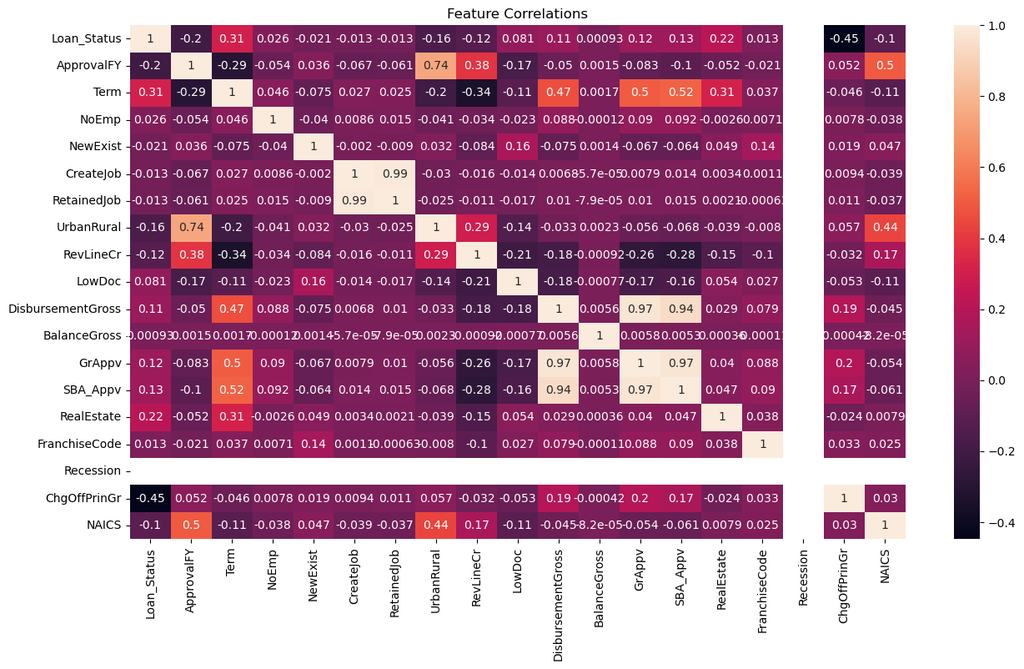

```python
corr = df_num.corr()
sns.heatmap(corr, annot = True).set(title='Feature Correlations')
```

# Analysis

### Term and DisbursementGross have a strong positive correlation (.47), which means that loans with larger terms are usually larger.

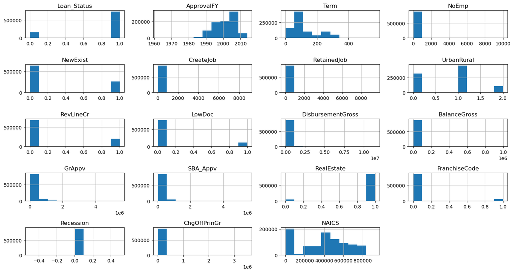

```python
# Now we'll check the distribution of numerical variable
df_num.hist()
plt.tight_layout()
plt.show()
```

```python
# The distribution of loan terms isn't quite normal, so we'll have to scale it.
# DisbursementGross is also not normally distibuted andd since SBA_Appv and GrAppv are highly correlated with DisbursementGross hence they are also skewed
# Befor 1988 very few SBA loaan were taken.
```

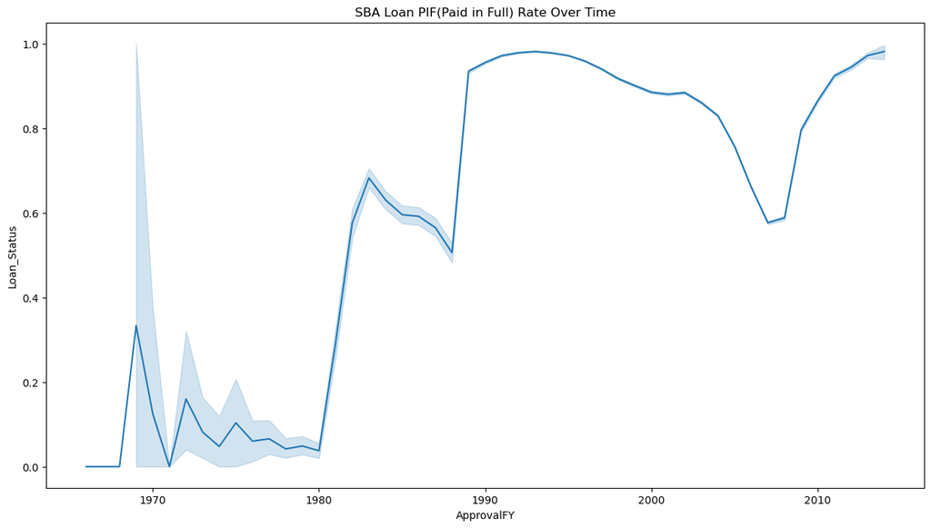

```python
#Now lets analyis loan payment over the years
sns.lineplot(x="ApprovalFY", y="Loan_Status", data=df1)
plt.title('SBA Loan PIF(Paid in Full) Rate Over Time')
plt.show()
```

```python
# From the above line chart it is quite evident that loans approved around 1990-2005 has higher percentage of being paid.
# Also it i quite evident that recession years (2007-2009) saw a significant dip in percentage of loan being repayed.
# loans before 1980 also have very les percentage of settlement which can be attributed to the low number of loans taken before 1980 as depicte in the ditribtion plot above.
```

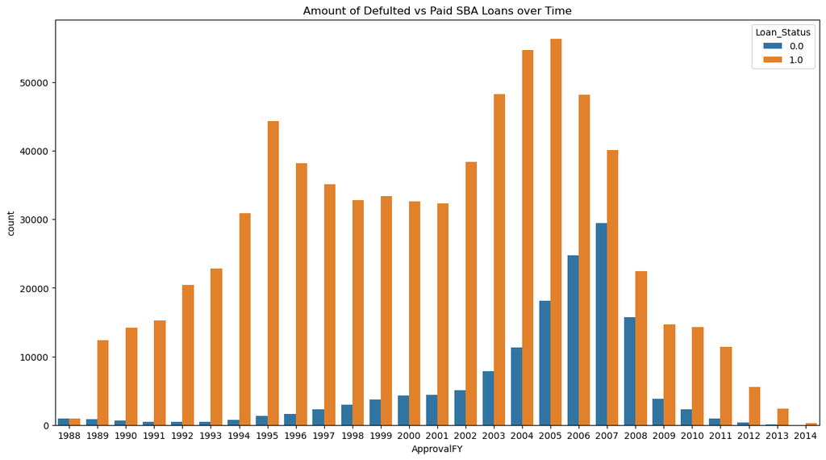

```python
# now we'll plot defaulted vs. paid loans over time to get another visual of which periods were more successful than others.
per= df1[df1['ApprovalFY'] >= 1988]
sns.countplot(x="ApprovalFY",data=per,hue="Loan_Status")
plt.title('Amount of Defulted vs Paid SBA Loans over Time')
plt.show()
```

```python
#Inference:

# Loans in period 2005 to 2008 defaulted the highest.
```

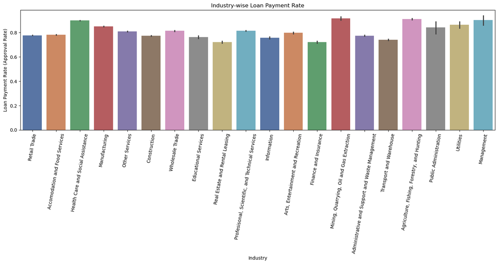

```python
# There is another column(NAICS that is industry type) in our dataset which can significantly impact the loan repayment. Let's see it's distribution
df1['NAICS']=df1['NAICS'].astype(str)
def ext(str1):
    s=str1[:2]
    return s
df1['NAICS']=df1['NAICS'].apply(lambda x: ext(x))

codes = {'11': 'Agriculture, Fishing, Forestry, and Hunting',
      '21': 'Mining, Quarrying, Oil and Gas Extraction',
      '22': 'Utilities',
      '23': 'Construction',
      '31': 'Manufacturing',
      '32': 'Manufacturing',
      '33': 'Manufacturing',
      '42': 'Wholesale Trade',
      '44': 'Retail Trade',
      '45':'Retail Trade',
      '48':'Transport and Warehouse',
      '49': 'Transport and Warehouse',
      '51':'Information',
      '52': 'Finance and Insurance',
      '53':'Real Estate and Rental Leasing',
      '54':'Profesisonal, Scientific, and Technical Services',
      '55':'Management',
      '56':'Administrative and Support and Waste Management',
      '61':'Educational Services',
      '62':'Health Care and Social Assistance',
      '71': 'Arts, Entertainment and Recreation',
      '72':'Accomodation and Food Services',
      '81': 'Other Services',
      '92':'Public Administration'}

df1['NAICS']=df1['NAICS'].map(codes)
sns.barplot(x='NAICS', y='Loan_Status', data=df1, palette="deep")
plt.xticks(rotation=80)
plt.title('Industry-wise Loan Payment Rate')
plt.xlabel('Industry')
plt.ylabel('Loan Payment Rate (Approval Rate)')
plt.tight_layout()
plt.show()
```

```python
# Inference
# It is quiet evident from above plot that Health care,Mining,Agriculture,Management are the leading industries that have highest loan repayment record.
```

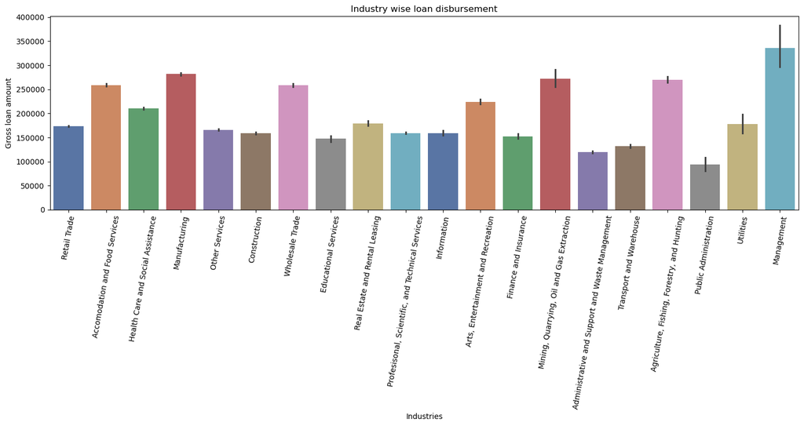

```python
#We'll now see which indutry got the maximum loan

sns.barplot(x=df1['NAICS'],y=df1['DisbursementGross'], palette = "deep")
plt.xticks(rotation=80)
plt.title("Industry wise loan disbursement")
plt.xlabel('Industries')
plt.ylabel('Gross loan amount')
plt.tight_layout()
plt.show()
```

```python
#Inference:
#It is quite evident that maximum loans were awarded to Manufacturing,Mining,Agriculture and Management indutries.
```

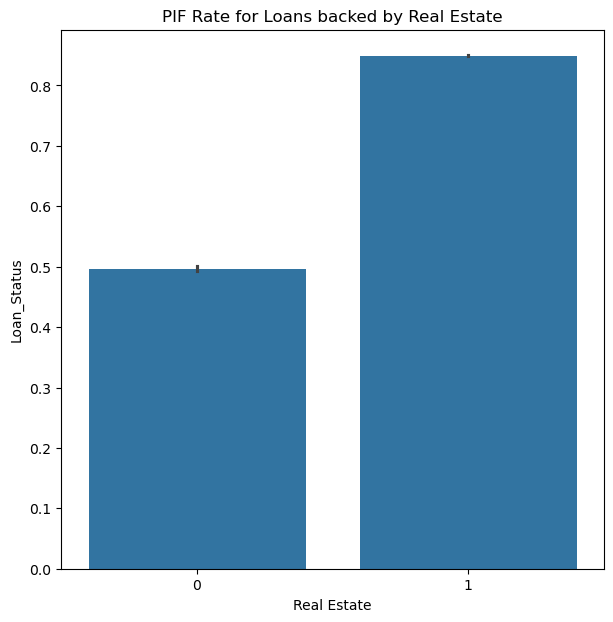

```python
#Now let's see how loans that were backed by real estate were paid

fig = plt.figure(figsize=(7,7))
sns.barplot(x="RealEstate", y="Loan_Status", data=df1)
plt.title('PIF Rate for Loans backed by Real Estate')
plt.xlabel('Real Estate')
plt.show()
```

```python
#So it's quite evident that loans that are backed by realestate have better chance of being repaid
```

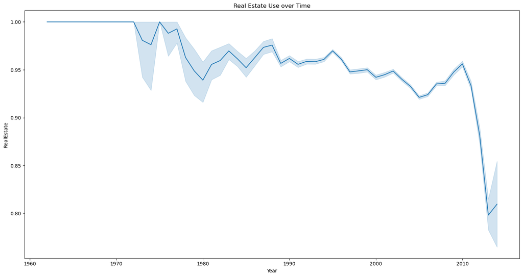

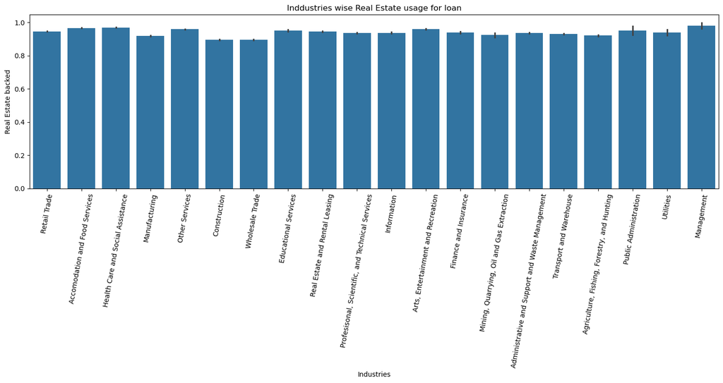

```python
# Now we'll analyze the pattern of usage of realestate as backup for loan repayment by various industries over time.

sns.lineplot(x='ApprovalFY',y='RealEstate',data=df1)
plt.xlabel('Year')
plt.title('Real Estate Use over Time')
plt.tight_layout()
plt.show()


sns.barplot(x=df1['NAICS'],y=df1['RealEstate'])
plt.xticks(rotation=80)
plt.title('Inddustries wise Real Estate usage for loan')
plt.xlabel('Industries')
plt.ylabel('Real Estate backed')
plt.tight_layout()



plt.show()
```

```python
#Now based on the corelation matrix and insights from other plots we'll remove columns that are insignificant

df1=df1.drop(['Bank','GrAppv','DisbursementGross','Name', 'City', 'ApprovalDate','Zip','BankState', 'DisbursementDate','ChgOffPrinGr','MIS_Status'],axis=1)
```

```python
df1['NAICS'].isna().sum()
```

```
201169
```

```python
state_rate = {'MT':.06, 'WY':.07,'VT':.07,'ND':.9,'SD':.9,'ME':.9,
            'NH':.1,'NM':.1,'NE':.1,'AK':.1,'IA':.1,'MN':.1,
            'RI':.1,'WI':.121,'MA':.127,'KS':.13,'WA':.13,'CT':.14,
            'ID':.15,'PA':.15,'OR':.15,'MO':.15,'HI':.15,'OK':.15,
            'MS':.16,'WV':.16,'OH':.16,'AL':.16,'AR':.17,'IN':.18,
            'UT':.17,'DE':.17,'CA':.18,'CO':.18,'VA':.18,'LA':.18,
            'NC':.18,'TX':.18,'MD':.19,'KY':.19,'SC':.19,'NY':.19,
            'NJ':.19,'AZ':.2,'TN':.2,'MI':.22,'NV':.22,'IL':.22,
            'GA':.22,'DC':.23,'FL':.25}
df1['State'] = df1['State'].map(state_rate)


industry_rate = {'Accomodation and Food Services':.22,
                 'Administrative and Support and Waste Management':.24,
                 'Agriculture, Fishing, Forestry, and Hunting':.089,
                 'Arts, Entertainment and Recreatiom':.21,
                 'Construction':.23,
                 'Educational Services':.24,
                 'Finance and Insurance':.28,
                 'Health Care and Social Assistance':.10,
                 'Information':.24,
                 'Management':.1,
                 'Manufacturing':.16,
                 'Mining, Quarrying, Oil and Gas Extraction':.08,
                 'Other Services':.2,
                 'Profesisonal, Scientific, and Technical Services':.18,
                 'Public Administration':.15,
                 'Real Estate and Rental Leasing':.29,
                 'Retail Trade':.22,
                 'Transport and Warehouse':.26,
                 'Utilities':.14,
                 'Wholesale Trade':.19}
df1['NAICS'] = df1['NAICS'].map(industry_rate)
```

```python
df1['NAICS'].fillna(df1['NAICS'].median(),inplace=True)
```

```python
df1['Loan_Status'].fillna(df1['Loan_Status'].mode()[0],inplace=True)
```

```python
df1.isna().sum()
```

```
State            0
NAICS            0
ApprovalFY       0
Term             0
NoEmp            0
NewExist         0
CreateJob        0
RetainedJob      0
FranchiseCode    0
UrbanRural       0
RevLineCr        0
LowDoc           0
BalanceGross     0
SBA_Appv         0
Loan_Status      0
RealEstate       0
Recession        0
dtype: int64
```

```python
df1.head()
```

|  | State | NAICS | ApprovalFY | Term | NoEmp | NewExist | CreateJob | RetainedJob | FranchiseCode | UrbanRural | RevLineCr | LowDoc | BalanceGross | SBA_Appv | Loan_Status | RealEstate | Recession |
| --- | --- | --- | --- | --- | --- | --- | --- | --- | --- | --- | --- | --- | --- | --- | --- | --- | --- |
| 0 | 0.180000 | 0.220000 | 1997 | 84 | 4 | 1.000000 | 0 | 0 | 0 | 0 | 0 | 1 | 0.000000 | 48000.000000 | 1.000000 | 1 | 0 |
| 1 | 0.180000 | 0.220000 | 1997 | 60 | 2 | 1.000000 | 0 | 0 | 0 | 0 | 0 | 1 | 0.000000 | 32000.000000 | 1.000000 | 1 | 0 |
| 2 | 0.180000 | 0.100000 | 1997 | 180 | 7 | 0.000000 | 0 | 0 | 0 | 0 | 0 | 0 | 0.000000 | 215250.000000 | 1.000000 | 1 | 0 |
| 3 | 0.150000 | 0.220000 | 1997 | 60 | 2 | 0.000000 | 0 | 0 | 0 | 0 | 0 | 1 | 0.000000 | 28000.000000 | 1.000000 | 1 | 0 |
| 4 | 0.250000 | 0.220000 | 1997 | 240 | 14 | 0.000000 | 7 | 7 | 0 | 0 | 0 | 0 | 0.000000 | 229000.000000 | 1.000000 | 1 | 0 |

```python
cnames=['ApprovalFY','Term','NoEmp','CreateJob','RetainedJob','SBA_Appv','BalanceGross']
sc=StandardScaler()
for col in cnames:
    df1[col] = sc.fit_transform(df1[col].values.reshape(-1,1))

df1.head()
```

|  | State | NAICS | ApprovalFY | Term | NoEmp | NewExist | CreateJob | RetainedJob | FranchiseCode | UrbanRural | RevLineCr | LowDoc | BalanceGross | SBA_Appv | Loan_Status | RealEstate | Recession |
| --- | --- | --- | --- | --- | --- | --- | --- | --- | --- | --- | --- | --- | --- | --- | --- | --- | --- |
| 0 | 0.180000 | 0.220000 | -0.686349 | -0.348364 | -0.100204 | 1.000000 | -0.035826 | -0.045521 | 0 | 0 | 0 | 1 | -0.002052 | -0.450965 | 1.000000 | 1 | 0 |
| 1 | 0.180000 | 0.220000 | -0.686349 | -0.651418 | -0.126953 | 1.000000 | -0.035826 | -0.045521 | 0 | 0 | 0 | 1 | -0.002052 | -0.520712 | 1.000000 | 1 | 0 |
| 2 | 0.180000 | 0.100000 | -0.686349 | 0.863853 | -0.060080 | 0.000000 | -0.035826 | -0.045521 | 0 | 0 | 0 | 0 | -0.002052 | 0.278113 | 1.000000 | 1 | 0 |
| 3 | 0.150000 | 0.220000 | -0.686349 | -0.651418 | -0.126953 | 0.000000 | -0.035826 | -0.045521 | 0 | 0 | 0 | 1 | -0.002052 | -0.538149 | 1.000000 | 1 | 0 |
| 4 | 0.250000 | 0.220000 | -0.686349 | 1.621488 | 0.033542 | 0.000000 | -0.006535 | -0.016283 | 0 | 0 | 0 | 0 | -0.002052 | 0.338053 | 1.000000 | 1 | 0 |

# Train-Test Split

```python
x=df1.drop(['Loan_Status'],axis=1)
y=df1['Loan_Status']
```

```python
xtrain,xtest,ytrain,ytest=train_test_split(x,y,test_size=.2,random_state=10)
```

# Defining Generic functions

#### Classification report function

```python
def report(model):
    ypredmodel=model.predict(xtest)
    return print(classification_report(ytest,ypredmodel))
```

```python
def reportp(model):
    ypredmodel=model.predict(xtest_pca)
    return print(classification_report(ytest,ypredmodel))
```

#### Confusion matrix function

```python
def conf_mat(model):
    ypredmodel=model.predict(xtest)
    cm = confusion_matrix(ytest, ypredmodel)
    disp=ConfusionMatrixDisplay(cm,display_labels=model.classes_)
    return disp.plot()
```

```python
def conf_matp(model):
    ypredmodel=model.predict(xtest_pca)
    cm = confusion_matrix(ytest, ypredmodel)
    disp=ConfusionMatrixDisplay(cm,display_labels=model.classes_)
    return disp.plot()
```

#### ROC curve funcction

```python
def roc_auc(model):
    ypredprob=model.predict_proba(xtest)[:,1]
    fpr,tpr,threshold=roc_curve(ytest,ypredprob)
    plt.plot(fpr,tpr,label=f'ROC-AUC Score:{round(roc_auc_score(ytest,ypredprob),3)}')
    plt.plot([0,1],[0,1],'r--')
    plt.title('ROC-AUC Curve')
    plt.xlabel('false positive rate')
    plt.plot('True positive rate')
```

```python
def roc_aucp(model):
    ypredprob=model.predict_proba(xtest_pca)[:,1]
    fpr,tpr,threshold=roc_curve(ytest,ypredprob)
    plt.plot(fpr,tpr,label=f'ROC-AUC Score:{round(roc_auc_score(ytest,ypredprob),3)}')
    plt.plot([0,1],[0,1],'r--')
    plt.title('ROC-AUC Curve')
    plt.xlabel('false positive rate')
    plt.plot('True positive rate')
```

# Generating Models

#### 1. Random Forest Classifier

```python
rfc1=RandomForestClassifier(oob_score=True)
rfc1.fit(xtrain,ytrain)
```

```
RandomForestClassifier(oob_score=True)
```

```python
rfc1.oob_score_
```

```
0.9445609051905586
```

```python
ypredrfc=rfc1.predict(xtest)
```

```python
rfc1_cr=report(rfc1)
```

```
              precision    recall  f1-score   support

         0.0       0.87      0.79      0.83     29970
         1.0       0.96      0.98      0.97    146413

    accuracy                           0.94    176383
   macro avg       0.91      0.88      0.90    176383
weighted avg       0.94      0.94      0.94    176383
```

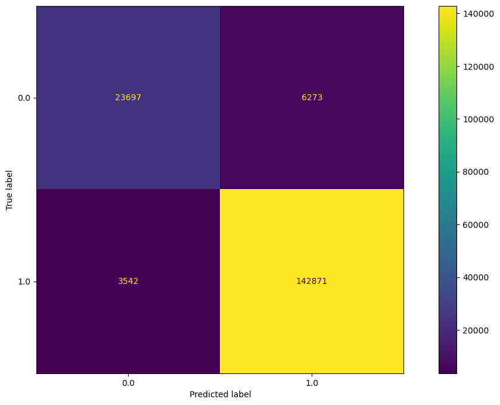

```python
rfc1_cm=conf_mat(rfc1)
```

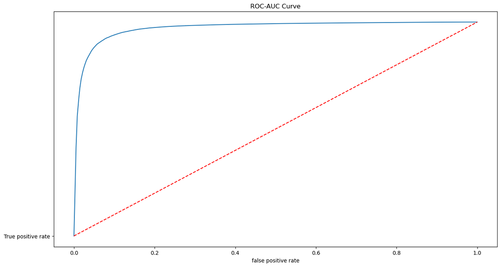

```python
rfc1_roc=roc_auc(rfc1)
```

```python
clf = RandomizedSearchCV(RandomForestClassifier(oob_score=True),{'n_estimators': [i for i in range(100,200,10)],'max_depth':[i for i in range(10,50,10)]},n_jobs=-1)
```

```python
clf.fit(xtrain,ytrain)
```

```
RandomizedSearchCV(estimator=RandomForestClassifier(oob_score=True), n_jobs=-1,
                   param_distributions={'max_depth': [10, 20, 30, 40],
                                        'n_estimators': [100, 110, 120, 130,
                                                         140, 150, 160, 170,
                                                         180, 190]})
```

```python
clf.best_estimator_
```

```
RandomForestClassifier(max_depth=40, n_estimators=170, oob_score=True)
```

```python
rf3=RandomForestClassifier(max_depth=40, n_estimators=170, oob_score=True,
                       random_state=10,n_jobs=-1)
rf3.fit(xtrain,ytrain)
```

```
RandomForestClassifier(max_depth=40, n_estimators=170, n_jobs=-1,
                       oob_score=True, random_state=10)
```

```python
ypred_rf3=rf3.predict(xtest)
```

```python
rf3_report=report(rf3)
```

```
              precision    recall  f1-score   support

         0.0       0.87      0.79      0.83     29970
         1.0       0.96      0.98      0.97    146413

    accuracy                           0.94    176383
   macro avg       0.91      0.88      0.90    176383
weighted avg       0.94      0.94      0.94    176383
```

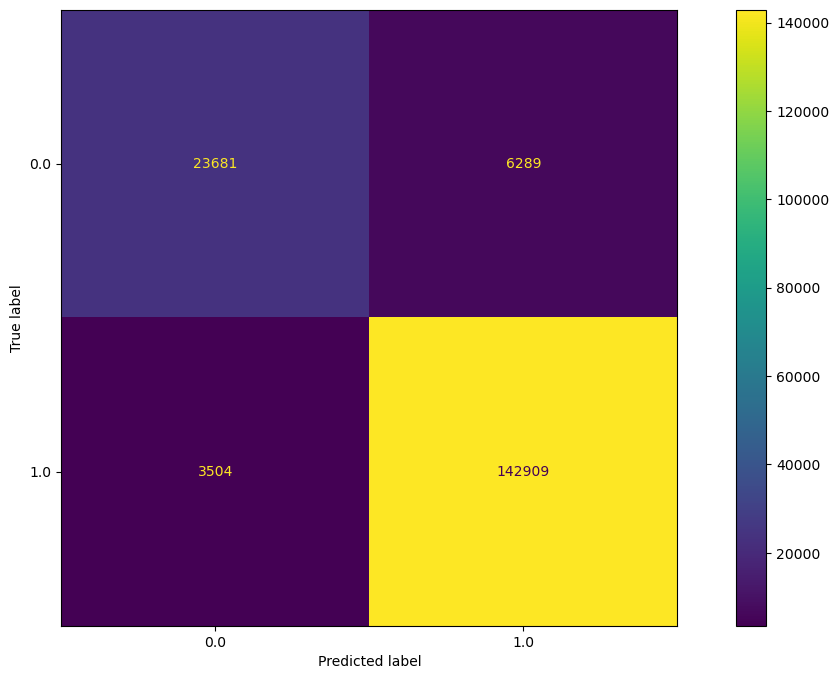

```python
rf3_cm=conf_mat(rf3)
```

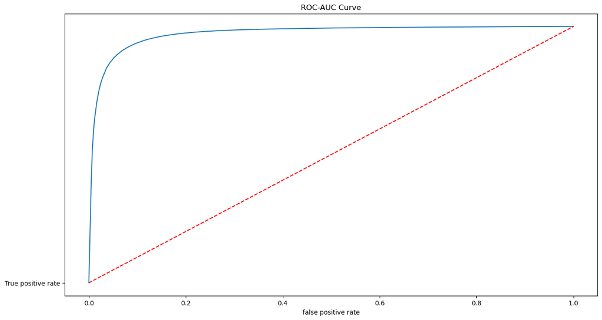

```python
rf3_roc=roc_auc(rf3)
```

#### 2.LogisticRegression

```python
from sklearn.linear_model import LogisticRegression
```

```python
lr = LogisticRegression()
lr.fit(xtrain,ytrain)
```

```
LogisticRegression()
```

```python
ypred_lr = lr.predict(xtest)
```

```python
lr_cr=report(lr)
```

```
              precision    recall  f1-score   support

         0.0       0.50      0.12      0.20     29970
         1.0       0.84      0.97      0.90    146413

    accuracy                           0.83    176383
   macro avg       0.67      0.55      0.55    176383
weighted avg       0.79      0.83      0.78    176383
```

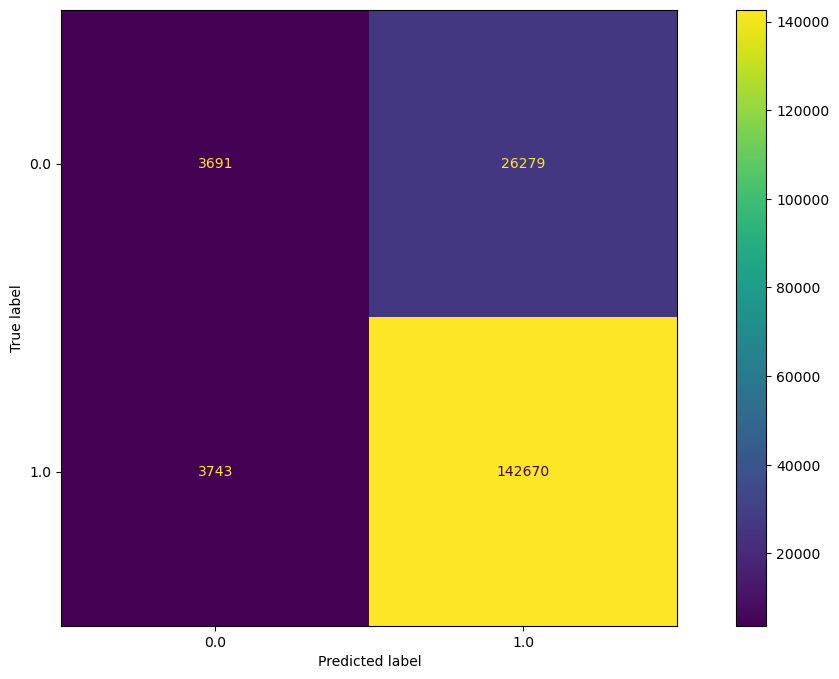

```python
lr_cm=conf_mat(lr)
```

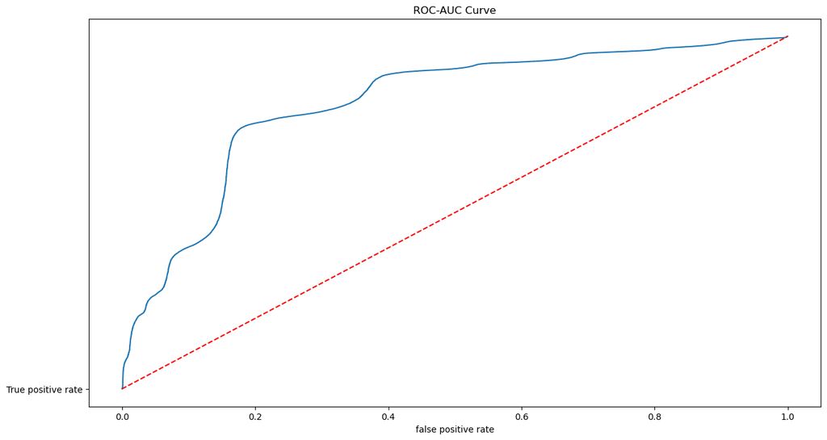

```python
lr_roc=roc_auc(lr)
```

#### 3. XGBoost

```python
tuning_parameters = {'learning_rate': [0.1, 0.2, 0.3, 0.4, 0.5, 0.6],
                     'max_depth': range(3,10),
                     'gamma': [0, 1, 2, 3, 4]}
xgb_model = XGBClassifier()
xgb_grid = GridSearchCV(estimator = xgb_model, param_grid = tuning_parameters, cv = 3, scoring = 'roc_auc')
```

```python
xgb_grid.fit(xtrain,ytrain)
```

```
GridSearchCV(cv=3,
             estimator=XGBClassifier(base_score=None, booster=None,
                                     callbacks=None, colsample_bylevel=None,
                                     colsample_bynode=None,
                                     colsample_bytree=None, device=None,
                                     early_stopping_rounds=None,
                                     enable_categorical=False, eval_metric=None,
                                     feature_types=None, gamma=None,
                                     grow_policy=None, importance_type=None,
                                     interaction_constraints=None,
                                     learning_rate=None,...
                                     max_cat_threshold=None,
                                     max_cat_to_onehot=None,
                                     max_delta_step=None, max_depth=None,
                                     max_leaves=None, min_child_weight=None,
                                     missing=nan, monotone_constraints=None,
                                     multi_strategy=None, n_estimators=None,
                                     n_jobs=None, num_parallel_tree=None,
                                     random_state=None, ...),
             param_grid={'gamma': [0, 1, 2, 3, 4],
                         'learning_rate': [0.1, 0.2, 0.3, 0.4, 0.5, 0.6],
                         'max_depth': range(3, 10)},
             scoring='roc_auc')
```

```python
print('Best parameters for XGBoost classifier: ', xgb_grid.best_params_, '\n')
```

```
Best parameters for XGBoost classifier:  {'gamma': 0, 'learning_rate': 0.2, 'max_depth': 9}
```

```python
xgb_grid_model = XGBClassifier(learning_rate = xgb_grid.best_params_.get('learning_rate'),
                               max_depth = xgb_grid.best_params_.get('max_depth'),
                              gamma = xgb_grid.best_params_.get('gamma'))
xgb_model = xgb_grid_model.fit(xtrain,ytrain)
```

```python
ypred_xgb=xgb_model.predict(xtest)
```

```python
report_xgb=report(xgb_model)
```

```
              precision    recall  f1-score   support

         0.0       0.86      0.82      0.84     29970
         1.0       0.96      0.97      0.97    146413

    accuracy                           0.95    176383
   macro avg       0.91      0.90      0.90    176383
weighted avg       0.95      0.95      0.95    176383
```

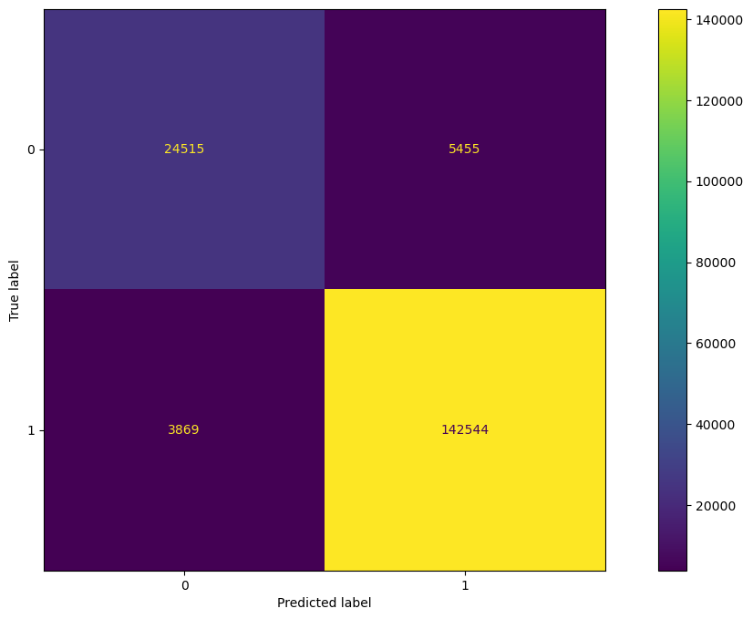

```python
con_xgb=conf_mat(xgb_model)
```

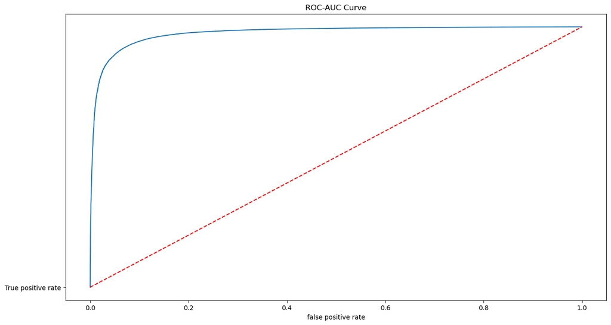

```python
auc_xgb=roc_auc(xgb_model)
```

# Model building using principle component analysis (PCA)

```python
from sklearn.decomposition import PCA
```

```python
pca=PCA(n_components=None)
```

```python
xtrain_pca=pca.fit_transform(xtrain)
xtest_pca=pca.fit_transform(xtest)
```

```python
pca.explained_variance_ratio_
```

```
array([2.80052047e-01, 2.51886329e-01, 1.60484668e-01, 1.37869912e-01,
       6.53458493e-02, 3.14849588e-02, 2.17748589e-02, 1.90858902e-02,
       1.24603491e-02, 7.64073643e-03, 6.63412119e-03, 2.76571465e-03,
       1.54751081e-03, 7.48567716e-04, 2.18486062e-04, 0.00000000e+00])
```

```python
pca=PCA(n_components=14)
xtrain_pca=pca.fit_transform(xtrain)
xtest_pca=pca.fit_transform(xtest)
```

#### 1.PCA with Logistic Regression

```python
lrp = LogisticRegression()
lrp.fit(xtrain_pca,ytrain)
```

```
LogisticRegression()
```

```python
ypred_lrp = lrp.predict(xtest_pca)
```

```python
lrp_rep=reportp(lrp)
```

```
              precision    recall  f1-score   support

         0.0       0.04      0.02      0.02     29970
         1.0       0.82      0.92      0.87    146413

    accuracy                           0.76    176383
   macro avg       0.43      0.47      0.44    176383
weighted avg       0.69      0.76      0.72    176383
```

```python
for i in range(1,16):
    pca = PCA(n_components=i)
    xtrain_pca = pca.fit_transform(xtrain)
    xtest_pca = pca.transform(xtest)

    lrp1 = LogisticRegression()
    lrp1.fit(xtrain_pca,ytrain)
    y_pred = lrp1.predict(xtest_pca)
    print(recall_score(ytest,y_pred))
```

```
1.0
```

```
0.9985315511600746
```

```
0.9988935408741028
```

```
0.9989755008093544
```

```
0.9987296210035994
```

```
0.9777205576007595
```

```
0.9781166972878091
```

```
0.9777478775791767
```

```
0.9786699268507578
```

```
0.975193459597167
```

```
0.9754325094083176
```

```
0.976900958248243
```

```
0.9769829181834946
```

```
0.9770102381619119
```

```
0.9764365186151502
```

#### 2.PCA with XGBoost

```python
xgb_grid_model = XGBClassifier(learning_rate = xgb_grid.best_params_.get('learning_rate'),
                               max_depth = xgb_grid.best_params_.get('max_depth'),
                              gamma = xgb_grid.best_params_.get('gamma'))
```

```python
for i in range(1,16):
    pca = PCA(n_components=i)
    xtrain_pca = pca.fit_transform(xtrain)
    xtest_pca = pca.transform(xtest)

    xgb_grid_model = XGBClassifier(learning_rate = xgb_grid.best_params_.get('learning_rate'),
                               max_depth = xgb_grid.best_params_.get('max_depth'),
                              gamma = xgb_grid.best_params_.get('gamma'))
    xgb_grid_model.fit(xtrain_pca,ytrain)
    y_pred_xgbp = xgb_grid_model.predict(xtest_pca)
    print(recall_score(ytest,y_pred_xgbp))
```

```
0.9798924958849282
0.9528730372303006
0.9614446804587025
0.9607070410414376
0.958268732967701
0.9607480210090634
0.9649006577284804
0.9652558174479042
0.9659251569191261
0.9666696263309952
0.966485216476679
0.9670316160450233
0.9676121655863892
0.9683976149658842
0.9685342148579703
```

#### 3. PCA with Random Forest

```python
rfp=RandomForestClassifier(max_depth=30, n_estimators=180, oob_score=True,
                       random_state=10,n_jobs=-1)
for i in range(1,16):
    pca = PCA(n_components=i)
    xtrain_pca = pca.fit_transform(xtrain)
    xtest_pca = pca.transform(xtest)


    rfp.fit(xtrain_pca,ytrain)
    y_pred_rfp = rfp.predict(xtest_pca)
    print(recall_score(ytest,y_pred_rfp))
```

```
0.9455171330414649
0.9497448997015292
0.9637600486295615
0.9651875175018612
0.9677624254676839
0.9658022170162486
0.9692377043022136
0.9704056333795497
0.9698455738219967
0.9697841038705579
0.9698660638058096
0.9702622034928592
0.9713140226619221
0.9718399322464535
0.9724614617554452
```